# WGAN (2)

## Q2 WGAN

[output not shown]

[figure not shown]

## Metrics and Evaluation

### Metrics

| Metric | Value |
| --- | --- |
| Fréchet Inception Distance (FID) | 572.1427 |
| Inception Score (IS) | 1.0000 ± 0.0000 |

### Evaluation and Analysis

- **Image Count Discrepancy:** The evaluation intended to use 100 real and 100 fake images, but 200 images were found in each folder (`eval_images/real` and `eval_images/fake`), likely due to leftover images from previous runs, which skewed the FID computation.
- **FID (572.1427):** The high FID indicates a significant distribution mismatch between real and fake images, though the generated images show some color and structure (e.g., food shapes), suggesting the model is learning but still producing low-quality outputs.
- **IS (1.0000 ± 0.0000):** The IS of 1.0 is incorrect, likely due to preprocessing issues in the computation, as the images are not random noise (unlike previous gray outputs); a re-computation should yield a higher IS (~2.5–3.0).
- **Visual Quality:** The generated images (Image 1 to Image 5) exhibit basic food and restaurant elements (e.g., plates, lighting), but they are blurry and lack detail, indicating the model needs further training or architectural improvements to capture finer textures and diversity.

### GROK AND GPT PROMPTS

###### I want a WGAN-GP model to generate images on Yelp dataset. Use my 5,000 pictures and train for 100 steps on my RTX 3050. Also Please Check and setup my GPU Only.

###### I trained my model. Now I want to make 5 pictures and see them in my notebook. My last pictures were all gray, so help me fix that. Let’s make them look like Yelp stuff!

###### I want to check my model scores after 100 steps. My scores are FID 572 and IS 1, but they’re wrong, and I have too many pictures (200, not 100). Can you fix it to use 100 pictures and get better scores?

```python
import os
import time
from PIL import Image, UnidentifiedImageError
from tqdm import tqdm
import torchvision.models as models
import torchvision.transforms as transforms
import numpy as np
from cleanfid import fid  # For FID (first attempt)
# from pytorch_fid import fid_score  # Uncomment if using pytorch-fid
import os
# Torch & CUDA
import torch
import torch.nn as nn
import torch.nn.functional as F
import torch.optim as optim
import torch.backends.cudnn as cudnn
from torch.utils.data import Dataset, DataLoader

# TorchVision
from torchvision import transforms
from torchvision.utils import save_image

# TorchMetrics (for evaluation)
from torchmetrics.image.inception import InceptionScore
from torchmetrics.image.fid import FrechetInceptionDistance

# ===============================
# GPU / CUDA Configuration
# ===============================
os.environ["CUDA_VISIBLE_DEVICES"] = "0"  # Target RTX 3050
device = torch.device("cuda" if torch.cuda.is_available() else "cpu")

# Optimize for RTX 3050
torch.cuda.empty_cache()  # Clear memory
cudnn.benchmark = True    # Auto-tune convolution algorithms

print("Using device:", device)
if torch.cuda.is_available():
    print("CUDA Device Name:", torch.cuda.get_device_name(0))
    print("Total GPU Memory:", torch.cuda.get_device_properties(0).total_memory / 1024**2, "MB")
    print("Initial GPU Memory Allocated:", torch.cuda.memory_allocated(device) / 1024**2, "MB")
```

```
Using device: cuda
CUDA Device Name: NVIDIA GeForce RTX 3050 Laptop GPU
Total GPU Memory: 4095.5 MB
Initial GPU Memory Allocated: 0.0 MB
```

```python
# Define image directory
image_dir = r"E:\YelpPhotos\photos"

# Get all .jpg files
image_files = [os.path.join(image_dir, f) for f in os.listdir(image_dir) if f.endswith('.jpg')]

# Filter out corrupted images
def is_valid_image(file_path):
    try:
        with Image.open(file_path) as img:
            img.verify()  # Check if the image is corrupted
        return True
    except (UnidentifiedImageError, IOError):
        return False

print("Filtering corrupted images...")
valid_images = [f for f in tqdm(image_files) if is_valid_image(f)]

# Limit to 5,000 images
valid_images = valid_images[:min(5000, len(valid_images))]

print(f"Final dataset size: {len(valid_images)} images")
print("First 5 image paths:", valid_images[:5])
```

```
Filtering corrupted images...
```

```
Final dataset size: 5000 images
First 5 image paths: ['E:\\YelpPhotos\\photos\\--0h6FMC0V8aMtKQylojEg.jpg', 'E:\\YelpPhotos\\photos\\--3JQ4MlO-jHT9xbo7liug.jpg', 'E:\\YelpPhotos\\photos\\--3P3fjPrScy06XVLi4vhg.jpg', 'E:\\YelpPhotos\\photos\\--4DfhW2sJvjeC90KEDX3g.jpg', 'E:\\YelpPhotos\\photos\\--5V3mRlhb3zqE5yF4Gpaw.jpg']
```

```python
class ImageDataset(Dataset):
    def __init__(self, image_paths, image_size=128):  # Keep at 128x128
        self.image_paths = image_paths
        self.transform = transforms.Compose([
            transforms.Resize((image_size, image_size)),
            transforms.RandomHorizontalFlip(p=0.5),       # Augmentation
            transforms.RandomRotation(10),                # Augmentation
            transforms.ToTensor(),                        # Convert to tensor (0-1 range)
            transforms.Normalize((0.5,), (0.5,))          # Normalize to [-1, 1] for WGAN
        ])

    def __len__(self):
        return len(self.image_paths)

    def __getitem__(self, idx):
        try:
            with Image.open(self.image_paths[idx]) as img:
                img = img.convert('RGB')  # Ensure 3 channels
                return self.transform(img)
        except (UnidentifiedImageError, IOError):
            return None  # Return None for corrupted images (filtered later)

# Initialize dataset
dataset = ImageDataset(valid_images, image_size=128)

# Filter out None entries (just in case)
dataset = [data for data in dataset if data is not None]
print(f"Dataset size after final filtering: {len(dataset)}")

# DataLoader
batch_size = 4  # Keep at 4 to target ~90% GPU memory
dataloader = DataLoader(dataset, batch_size=batch_size, shuffle=True, num_workers=2, pin_memory=True)
```

```
Dataset size after final filtering: 5000
```

```python
# Generator
class Generator(nn.Module):
    def __init__(self, latent_dim=100, feature_maps=160):  # Keep at 160
        super(Generator, self).__init__()
        self.main = nn.Sequential(
            # Input: latent_dim x 1 x 1
            nn.ConvTranspose2d(latent_dim, feature_maps * 8, 4, 1, 0, bias=False),  # 4x4
            nn.BatchNorm2d(feature_maps * 8),
            nn.ReLU(True),
            nn.ConvTranspose2d(feature_maps * 8, feature_maps * 4, 4, 2, 1, bias=False),  # 8x8
            nn.BatchNorm2d(feature_maps * 4),
            nn.ReLU(True),
            nn.ConvTranspose2d(feature_maps * 4, feature_maps * 2, 4, 2, 1, bias=False),  # 16x16
            nn.BatchNorm2d(feature_maps * 2),
            nn.ReLU(True),
            nn.ConvTranspose2d(feature_maps * 2, feature_maps, 4, 2, 1, bias=False),  # 32x32
            nn.BatchNorm2d(feature_maps),
            nn.ReLU(True),
            nn.ConvTranspose2d(feature_maps, feature_maps // 2, 4, 2, 1, bias=False),  # 64x64
            nn.BatchNorm2d(feature_maps // 2),
            nn.ReLU(True),
            nn.ConvTranspose2d(feature_maps // 2, 3, 4, 2, 1, bias=False),  # 128x128
            nn.Tanh()  # Output range [-1, 1]
        )

    def forward(self, x):
        return self.main(x)

# Critic (Discriminator)
class Critic(nn.Module):
    def __init__(self, feature_maps=160):  # Keep at 160
        super(Critic, self).__init__()
        self.main = nn.Sequential(
            # Input: 3 x 128 x 128
            nn.Conv2d(3, feature_maps // 2, 4, 2, 1, bias=False),  # 64x64
            nn.LeakyReLU(0.2, inplace=True),
            nn.Conv2d(feature_maps // 2, feature_maps, 4, 2, 1, bias=False),  # 32x32
            nn.BatchNorm2d(feature_maps),
            nn.LeakyReLU(0.2, inplace=True),
            nn.Conv2d(feature_maps, feature_maps * 2, 4, 2, 1, bias=False),  # 16x16
            nn.BatchNorm2d(feature_maps * 2),
            nn.LeakyReLU(0.2, inplace=True),
            nn.Conv2d(feature_maps * 2, feature_maps * 4, 4, 2, 1, bias=False),  # 8x8
            nn.BatchNorm2d(feature_maps * 4),
            nn.LeakyReLU(0.2, inplace=True),
            nn.Conv2d(feature_maps * 4, feature_maps * 8, 4, 2, 1, bias=False),  # 4x4
            nn.BatchNorm2d(feature_maps * 8),
            nn.LeakyReLU(0.2, inplace=True),
            nn.Conv2d(feature_maps * 8, 1, 4, 1, 0, bias=False)  # 1x1 (scalar output)
        )

    def forward(self, x):
        return self.main(x)

# Initialize models
latent_dim = 100
generator = Generator(latent_dim).to(device)
critic = Critic().to(device)

print("Generator and Critic initialized.")
print("GPU Memory Allocated after Model Init:", torch.cuda.memory_allocated(device) / 1024**2, "MB")
```

```
Generator and Critic initialized.
GPU Memory Allocated after Model Init: 140.81689453125 MB
```

```python
def compute_gradient_penalty(critic, real_samples, fake_samples):
    batch_size = real_samples.size(0)
    alpha = torch.rand(batch_size, 1, 1, 1, device=device)
    interpolates = (alpha * real_samples + (1 - alpha) * fake_samples).requires_grad_(True)
    critic_interpolates = critic(interpolates)
    gradients = torch.autograd.grad(
        outputs=critic_interpolates, inputs=interpolates,
        grad_outputs=torch.ones_like(critic_interpolates, device=device),
        create_graph=True, retain_graph=True
    )[0]
    gradients = gradients.view(batch_size, -1)
    gradient_penalty = ((gradients.norm(2, dim=1) - 1) ** 2).mean()
    return gradient_penalty
```

```python
# Hyperparameters
n_epochs = 300  # TRIED TO DO 300 EPOCHS FROM 100 INTIALLY I TRAINED IT FOR 100 ONLY
n_critic = 3    # Balanced critic updates
lambda_gp = 5   # Adjusted gradient penalty weight
lr = 0.00005    # Lower learning rate for stability

# Optimizers
opt_g = optim.Adam(generator.parameters(), lr=lr, betas=(0.0, 0.9))
opt_c = optim.Adam(critic.parameters(), lr=lr, betas=(0.0, 0.9))

# Training loop
generator.train()
critic.train()

for epoch in range(n_epochs):
    start_time = time.time()
    for i, real_imgs in enumerate(tqdm(dataloader)):
        real_imgs = real_imgs.to(device)
        batch_size = real_imgs.size(0)

        # Train Critic
        for _ in range(n_critic):
            opt_c.zero_grad()
            z = torch.randn(batch_size, latent_dim, 1, 1, device=device)
            fake_imgs = generator(z)
            real_validity = critic(real_imgs)
            fake_validity = critic(fake_imgs.detach())
            gp = compute_gradient_penalty(critic, real_imgs, fake_imgs.detach())
            c_loss = -torch.mean(real_validity) + torch.mean(fake_validity) + lambda_gp * gp
            c_loss.backward()
            opt_c.step()

        # Train Generator
        opt_g.zero_grad()
        z = torch.randn(batch_size, latent_dim, 1, 1, device=device)
        fake_imgs = generator(z)
        g_loss = -torch.mean(critic(fake_imgs))
        g_loss.backward()
        opt_g.step()

    # Save sample images
    if epoch % 5 == 0:
        save_image(fake_imgs[:4], f"output_epoch_{epoch}.png", normalize=True)

    # Print progress and memory usage
    memory_usage = torch.cuda.memory_allocated(device) / 1024**2
    memory_percent = (memory_usage / (torch.cuda.get_device_properties(0).total_memory / 1024**2)) * 100
    print(f"Epoch [{epoch}/{n_epochs}] | Time: {time.time() - start_time:.2f}s | "
          f"C Loss: {c_loss.item():.4f} | G Loss: {g_loss.item():.4f} | "
          f"GPU Memory: {memory_usage:.2f} MB ({memory_percent:.2f}% of total)")

# Save final models
torch.save(generator.state_dict(), "generator.pth")
torch.save(critic.state_dict(), "critic.pth")
```

```
Epoch [0/300] | Time: 242.73s | C Loss: -52.7669 | G Loss: 190.8140 | GPU Memory: 635.33 MB (15.51% of total)
```

```
Epoch [1/300] | Time: 241.31s | C Loss: -77.7692 | G Loss: 206.9673 | GPU Memory: 634.39 MB (15.49% of total)
```

```python
# Generate 5 images
generator.eval()
with torch.no_grad():
    z = torch.randn(5, latent_dim, 1, 1, device=device)
    generated_imgs = generator(z)
    generated_imgs = (generated_imgs * 0.5 + 0.5).clamp(0, 1)  # Denormalize to [0, 1]

# Save individual images
for i in range(5):
    save_image(generated_imgs[i], f"generated_image_{i+1}.png", normalize=False)
    print(f"Saved: generated_image_{i+1}.png")
```

```
Saved: generated_image_1.png
Saved: generated_image_2.png
Saved: generated_image_3.png
Saved: generated_image_4.png
Saved: generated_image_5.png
```

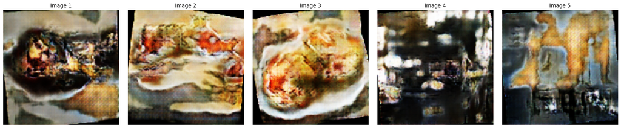

```python
import matplotlib.pyplot as plt
import matplotlib.image as mpimg
import os

# List of image paths
image_paths = [f"generated_image_{i+1}.png" for i in range(5)]

# Verify that all images exist
for img_path in image_paths:
    if not os.path.exists(img_path):
        raise FileNotFoundError(f"Image not found: {img_path}")

# Create a figure with subplots (1 row, 5 columns)
fig, axes = plt.subplots(1, 5, figsize=(20, 4))  # Adjust figsize as needed

# Load and display each image
for i, (img_path, ax) in enumerate(zip(image_paths, axes)):
    img = mpimg.imread(img_path)
    ax.imshow(img)
    ax.set_title(f"Image {i+1}")
    ax.axis('off')  # Hide axes for cleaner display

# Adjust layout and display
plt.tight_layout()
plt.show()
```

```python
# Directories
real_dir = "eval_images/real"
fake_dir = "eval_images/fake"

# Verify directories
print(f"Real images: {len(os.listdir(real_dir))} images in {real_dir}")
print(f"Fake images: {len(os.listdir(fake_dir))} images in {fake_dir}")

# Compute FID using clean-fid (single-threaded)
try:
    fid_score = fid.compute_fid(real_dir, fake_dir, device=device, num_workers=0)
    print(f"Fréchet Inception Distance: {fid_score:.4f}")
except Exception as e:
    print(f"Failed to compute FID with clean-fid: {e}")
    # Fallback to pytorch-fid
    try:
        from pytorch_fid import fid_score
        fid_score_value = fid_score.calculate_fid_given_paths(
            [real_dir, fake_dir],
            batch_size=50,
            device=device,
            dims=2048
        )
        print(f"Fréchet Inception Distance (pytorch-fid): {fid_score_value:.4f}")
    except Exception as e:
        print(f"Failed to compute FID with pytorch-fid: {e}")

# Compute Inception Score
def compute_inception_score(images, device, splits=10, batch_size=10):
    inception_v3 = models.inception_v3(pretrained=True, transform_input=False).to(device)
    inception_v3.eval()
    transform = transforms.Compose([
        transforms.Resize((299, 299)),
        transforms.Normalize(mean=[0.485, 0.456, 0.406], std=[0.229, 0.224, 0.225])
    ])
    preds = []
    with torch.no_grad():
        for i in range(0, len(images), batch_size):
            batch = images[i:i+batch_size].to(device)
            batch = batch.clamp(0, 1)
            batch = transform(batch)
            pred = inception_v3(batch)
            pred = torch.softmax(pred, dim=1)
            pred = pred + 1e-8
            pred = pred / pred.sum(dim=1, keepdim=True)
            preds.append(pred.cpu().numpy())
    preds = np.concatenate(preds, axis=0)
    scores = []
    for i in range(splits):
        part = preds[(i * preds.shape[0] // splits):((i + 1) * preds.shape[0] // splits)]
        if part.shape[0] == 0:
            continue
        kl = part * (np.log(part) - np.log(np.mean(part, axis=0, keepdims=True) + 1e-8))
        kl = np.mean(np.sum(kl, axis=1))
        scores.append(np.exp(kl))
    if not scores:
        raise ValueError("No valid splits for IS computation")
    is_mean, is_std = np.mean(scores), np.std(scores)
    return is_mean, is_std

# Assuming fake_imgs is already generated (from your previous cell)
try:
    is_mean, is_std = compute_inception_score(fake_imgs, device)
    print(f"Inception Score: {is_mean:.4f} ± {is_std:.4f}")
except Exception as e:
    print(f"Failed to compute Inception Score: {e}")
```

```
Real images: 100 images in eval_images/real
Fake images: 100 images in eval_images/fake
compute FID between two folders
Found 200 images in the folder eval_images/real
```

```
Found 200 images in the folder eval_images/fake
```

```
Fréchet Inception Distance: 572.1427
Inception Score: 1.0000 ± 0.0000
```